# H2H Satisfaction Survey Results Overview

### Question 1

Overall, how satisfied are you with the H2H Network to date?

Please rank 1 not at all satisfied and 5 is very satisfied.

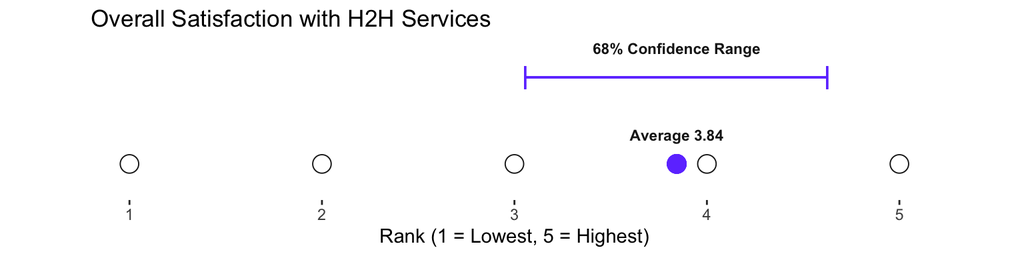

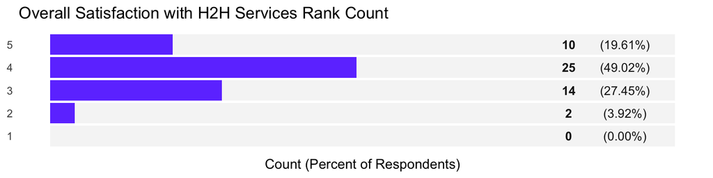

### Comments on This Question

GNC Technical Alliance, Technical Support Team

Score:4

I really value the network in general, but wish that we had more time to engage. Sometimes don’t feel like we are the right fit for the network, but do also feel very welcomed.

Global Public Policy Institute (GPPi)

Score:3

I continue to support the H2H idea, but it became clear over time that the network is much less relevant to our work than I initially thought.

DAHLIA

Score:2

We are not involved enough to be specific, our expertise is evaluation, communication which are fields for which we dont have much info or feedback from H2H

CALP Network

Score:4

We are not significantly engaged in the H2H Network but we do appreciate H2H efforts and resources available within the system.

The Geneva Learning Foundation

Score:4

Not very involved, but glad H2H exists and it looks from afar as if it is useful to members. Still believe it’s very much needed.

Humanitarian Academy for Development

Score:3

Positive feedback: When projects are live, H2H are a very supportive, flexible, and professional client to work with. Areas for improvement: Funding calls are often delayed following an emergency, tight timeframe to apply once announced, extensive application requirements, funding amounts often quite small, and there is a lot of competition for each call.

RE:ACT Disaster Response

Score:4

We have not yet fully utilised the services the network provides and am seeking to better understand and do more together.

Edge Effect

Score:3

We often cannot talk part in calls that occur in the wee hours in Australia, or in-person events like HNPW for which we have no funds to travel. As a social enterprise we are ineligible for funding through H2H, which limits what we can do. We have had limited corss-learning or partnership development opportunities with other H2H members, due in large part to those 2 factors. We hope to do more.

Humanitarian Logistics Association

Score:4

Very much value H2H membership and being part of a potentially change building network. H2H should communicate its position and value more widely

GISF

Score:3

So far we have not applied for H2H funding

iMMAP France

Score:3

iMMAP appreciates the support provided by the H2H network to kick-off new projects, especially in the context of sudden crises. In the meanwhile, the short duration of the projects combined with the financial and administrative requirements (e.g. small envelopes per project, financial reports to be provided for a 3-month project, impossibility to procure assets, threshold of the DSA rates, specific exchange rate to be used…) bring some difficulties for the teams to develop and implement the actions.

The New Humanitarian

Score:5

The H2H Network has been a great resource of support for us to be able to respond faster and better as a crisis occurs. In addition, the community aspect and resources like the crisis watch calls and Slack have been very useful for us to be aware of what others are doing, towards informing our journalism and considering potential collaborations.

Medical Aid films

Score:5

excellent and proactive network - thank you

CLEAR Global

Score:4

The H2H team is a good advocate for the value of member services in emergencies; there’s real value in supporting collaboration and coordination between members, including through funding; the H2H Fund has got quality support into early-phase responses where it would never otherwise have been; it would be good to find ways to build the evidence and analysis better collectively, but that is also a resource issue.

DEMAC

Score:4

We appreciate the regular information and meetings from H2H

Ground Truth Solutions

Score:4

Helpful for making us aware of other H2H orgs, funding, thinking outside the box

Humanitarian OpenStreetMap Team (HOT)

Score:3

The granting application process is very long considering limited amount of funds being distributed. Reporting is also quite demanding. Access to other organizations is a plus

Livestock Emergency Guidelines and Standards - LEGS

Score:3

We’re very supportive of the H2H Network, but find we sometimes slip through the gaps in terms of more active engagement with other members and the Network itself, because we are not operational.

Evidence Aid

Score:4

We struggle with time commitment vs. support from H2H

BBC Media Action

Score:3

Not always clear what criteria are for deciding how members are funded.

Humanitarian Advisory Group

Score:4

We love the information we get from H2H, the time difference makes it hard for us to be more engaged.

Aviation Sans Frontières International

Score:3

We feel that the added value we may bring into the humanitarian sector, especially last mile air transport and about accontability and efficiency of the humanitarian air transport sector has never been understood so far by the H2H Network management. We feel also that priority is given to ‘’soft’’ services (mapping, communication, etc., which are obviously important but other types of services are equally important. The delays to respond to funding proposals are too short and ‘’scoping mission’’ (e.g. DRC) are disapearing.

Insecurity Insight

Score:5

I find H2H very response to what members say. It also provides excellent learning and networking opportunities

Data Friendly Space

Score:5

H2H is doing important work to develop collaborative responses to emergent situations.

MapAction

Score:4

H2H needs to do more to promote the interests of its members (access to donors and core funding, access to humanitarian situations and global partners) for its members. Needs to look less like an NGO carving its own niche.

Groupe URD

Score:4

We don’t have yet many H2H projects - to be continued…

CartONG

Score:4

Grant mechanism provides new opportunities; visibility great; experience sharing interesting; could improve on joint projects with members

Sphere

Score:4

Very positive engagement with H2h. Community of practice element is strong as well as trainings. Work around activations also important

Research-Aid Networks

Score:4

It is a great resource bringing organizations together. We have found several new partners and projects though and with other H2H members. It would be helpful though to have more facilitated opportunities to network, learn about and interact with other member orgs.

Relief Applications

Score:5

We see it as an opportunity to create collaborations and find funding opportunities together.

Statistics Without Borders

Score:5

It’s a great team of organizations and periodically SWB is able to contribute and assist members.

Internews

Score:4

H2H builds relationships between agencies that can become relevant at a time of a crisis, but also helps set the agenda of the wider humanitarian system outside a particular response

Fondation Hirondelle

Score:3

H2H faced many challenges (change of people) and it remains difficult to get new donors

Groundwater Relief

Score:5

We are very happy to be a part of a network of specialist organisations supporting humanitarian interventions that can also help finance these through obtaining larger packets of money from large institutional donors

HQAI

Score:3

we do not sufficiently take advantage of the network at this stage. the accelerator fund seems to be an interesting tool and we need to get in touch to learn more and get involved. We can see increasing communication and activity from the H2H team, it is rather our team that is lacking time to get sufficiently involved. We believe that there could be a role for H2H in partnership brokering between members.

### Question 2

How engaged have you been in the network , either bilaterally with other members, or through the network’s processes or activities?

Please rank 1 is not at all involved and 5 is very involved. Please select how you have been engaged.

- Board member
- Regularly participating in calls and workshops
- engaging with the Communications Community of Practice of the Impact and Learning Advisory Group
- Participating in H2H Network-organized events at HNPW or elsewhere
- Other (please specify)

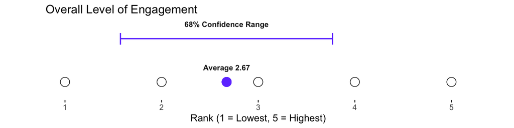

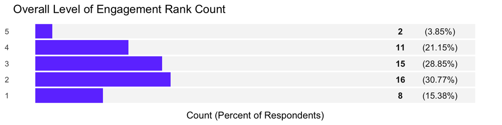

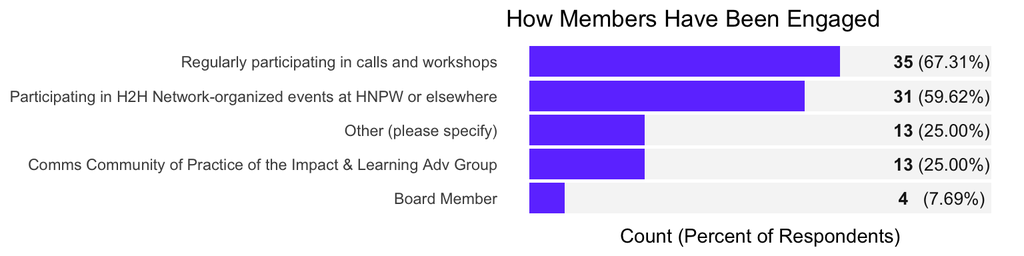

### Comments on This Question

GNC Technical Alliance, Technical Support Team

Score:2

As an organisation, we’ve mostly been engaged through Ben Allen, the Deputy Coordinator; he has recently left so I am taking this back over. We always participate in the crisis watch calls as well as other events that H2H holds; we really appreciate the capacity strengthening series. I believe Ben was on the Communications COP.

Global Public Policy Institute (GPPi)

Score:1

I was initially involved as a member of the (interim) board and by participating regularly in meetings. That participation has become dormant.

CALP Network

Score:2

We have engaged with the H2H Communications group

Humanitarian Academy for Development

Score:3

We will be attending HNPW in April 2023

RE:ACT Disaster Response

Score:3

Attending calls and F2F in Geneva

Edge Effect

Score:1

We hope to be more involved and see lots of potential for working with other H2H members. Location and other factors mentioned earlier create challenges.

Humanitarian Logistics Association

Score:3

Most valuable engagement to date has been with the H2H (BHA) innovation accelerator

Inter-agency Network for Education in Emergencies (INEE)

Score:2

Following communications

Fundación DARA Internacional

Score:1

Not this year, we have however received and used the information shared by the network

Medical Aid films

Score:5

very informative and helpful

International Health Partners

Score:3

We have been able to work with members outside of network events too

DEMAC

Score:2

bilateral meetings with H2H members

Livestock Emergency Guidelines and Standards - LEGS

Score:2

remaining in touch; one application for funding

Evidence Aid

Score:2

We participate in what we can when we can but have serious time constraints

BBC Media Action

Score:2

The team is supportive and efficient when we engage. It hasn’t been a priority globally given other things on.

Humanitarian Advisory Group

Score:2

We are still not exactly sure if as a social enterprise we are eligible to apply for H2H funds

Aviation Sans Frontières International

Score:1

We have been actively participating in 2020 but later it was no more a priority.

Insecurity Insight

Score:3

I am on the Board. I have attended every AGM. We have organized H2H events at the HNPW. We have collaborated with partners who we have met through the network.

Bioport

Score:3

Mostly networking work and attending H2H events and meetings

CartONG

Score:4

Membership comittee + communication and MEAL WG + GeOnG event

shelter centre

Score:3

directly with Network partners, applying to Network grants

Research-Aid Networks

Score:4

Working with other H2H members

Statistics Without Borders

Score:2

SWB has reached out to organizations who may need statistical assistance.

Internews

Score:3

We have set up collaboration with ACAPS, are attending calls and share expertise, contacts & other ways of helping to support the other H2H-members

Fondation Hirondelle

Score:2

we had also a lot of turn-over and were short-staffed

Groundwater Relief

Score:2

Part of H2H Horn of Africa intervention

HQAI

Score:2

see above

### Question 3

Have you collaborated with other members of the network?

If yes, was it a formal collaboration (might be a joint project or funding proposal) or an informal collaboration (might be ad-hoc information sharing) For example, a formal collaboration might be a joint project or funding proposal, an informal collaboration might be ad-hoc information sharing.

- Please share details. This is extremely useful information for us!

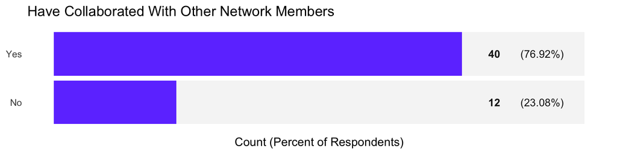

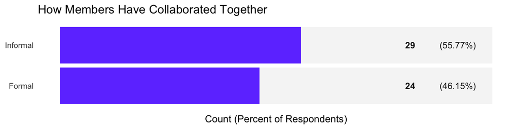

### Comments on This Question

The Humanitarian Leadership Academy

Connected with colleagues from ACAPS and the new humanitarian, this yet to yield collaboration

GNC Technical Alliance, Technical Support Team

With HAD, we submitted a joint proposal (unsuccessful) and then found some seed funding for the same work; we have now brought them onboard to do some joint work but it hasn’t taken place yet.

Global Public Policy Institute (GPPi)

We regularly collaborate with other “like-minded organisations” that are also H2H members.

CALP Network

Some H2H members are also CALP members and/or part of our targeted audience.

IMPACT Initiatives

Joint proposal with iMMAP and ACAPS, collaboration under UNDAC umbrella etc

Humanitarian Academy for Development

During live projects, we have collaborated and communicated with the following: CHS Alliance, RedR, Acaps, Insecurity Insight, Bioforce, Cartong, HLA

Field Ready

We subgranted to HOT under a HGC covid grant

Humanitarian Logistics Association

Sharing information and providing support on humanitarian logistics interventions and innovations

Fundación DARA Internacional

We did collaborate with DRC in 2021 for the organization of a workshop in Geneva, but not during 2022

iMMAP France

Together with ACAPs and IMPACT, iMMAP submitted two proposals to be funded by ECHO (one in Colombia and the other in Ethiopia)

The New Humanitarian

We partnered with Ground Truth Solutions on a survey of affected people in Haiti on what they think of aid. We also partner in other ways e.g. by featuring H2H partners/voices in our journalism, publishing Op-Eds, exchanging information informally etc.

Medical Aid films

contact with Clear Global and Research Aid Networks

International Health Partners

For our Ukraine response, we worked with Bioport for coordination of shipments of medicine

CLEAR Global

Program collaboration with Internews under non-H2H funding; informal collaboration and joint fundraising with REACH outside the H2H Fund; informal collaboration and fundraising with Medical Aid Films; informal collaboration with HOT, Data Friendly Space; engagement with CDAC as a member.

DEMAC

Supporting research by providing technical inputs and sharing the survey within our network, sharing information, in the process of using the service of another H2H member

Ground Truth Solutions

We collaborate semi regularly with the new humanitarian, cdac. Several H2H orgs collaborate from time to time to brainstorm on big issues.

Livestock Emergency Guidelines and Standards - LEGS

we collaborate with Sphere (and other standards initiatives) through the Humanitarian Standards Partnership, but not specifically via H2H

Evidence Aid

We work closely with TWB and have started collaborating more using the Slack channel which is extremely useful

BBC Media Action

We generally collaborate with other agencies doing media / communication in emergencies. It’s not always through H2H, but rather our existing relationships.

Humanitarian Advisory Group

Over the past years we have collaborated with the Centre for Humanitarian Leadership on research and events

Aviation Sans Frontières International

This collaboration is not part of H2H Network. We have set up a Rapid Response Mechansism with International Healt Partners.

Insecurity Insight

We did a joint project with MapAction in 2020. We informally collaborate with GISF a lot and we are starting to explore practical collaboration with CDAC

Data Friendly Space

We often meet with H2H members when we are traveling in an effort to understand the membership and look for collaborations. For instance, when in London meeting with Katie from Reach, we also met with Jonny Pinches to learn more about the work of his organisation.

MapAction

We constantly collaborate with H2H members, though this is not a function of us being in H2H as happened before.

Groupe URD

we work closely with CartONG on various projects

Bioport

Development of knowledge sharing tools with other H2H members

CartONG

Joint LTA with MapAction; several collaborations with HOT; MoU with TWB; etc.

shelter centre

liaised over a number of innovations to develop proposals

Research-Aid Networks

We have had several different collaborations with other members, at present we are putting together a formal partnership with Translators without Borders to work on information pertaining to Long Covid. We are also exploring collaboration and partnership opportunities with Medical Aid Films, though this is still at an exploratory phase, but would also pertain to dissemination of Long Covid information for communities, NGOs and medical staff internationally.

Relief Applications

Webinar and calls to create collaborations

Statistics Without Borders

Statistical support which is used to enhance the partner organization’s performance or understanding of data it has collected.

Internews

ACAPS collaboration on mapping/monitoring Information events & Trends - sharing of offices with Clear Global in Goma - informal conversations with GTS, Insecurity Insight which might turn into something more concrete and formal

HQAI

investigating future project with Clear. informal contact with sphere and HERE. CHS Alliance is a strategic partner with whom we have multiple projects and a MoU. We participated in congresses organised by CDAC and CartONG. And as said above: we are sure there could be interesting exchange and even collaboration with others, but lacking time and info.

### Question 4

If you have collaborated with other members, did the H2H Network core team facilitate this collaboration?

Please share details in the comment box

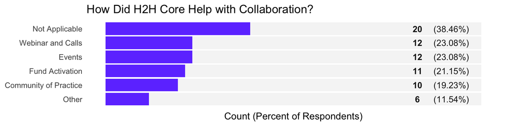

### Comments on This Question

Global Public Policy Institute (GPPi)

The collaboration was not facilitated by the core team.

CALP Network

We have generally engaged with our overlapping membership/audiences outside the H2H Network.

Humanitarian Academy for Development

Collaborated with other members during project implementation

CLEAR Global

Collaboration supported through the H2H Fund has seeded further collaboration on other projects.

Aviation Sans Frontières International

No

Insecurity Insight

Being able to meet other members during H2H events helped us to get to know each other. It then takes specific projects to actually practically collaborate

MapAction

I don’t think H2H did facilitate collaboration for us. I am not aware of new collaborations that H2H facilitated for us.

Groupe URD

support to the ongoing H2H accelerator for ADAPT

CartONG

Unsuccessful application with HOT to fund activation but discussion space encourages collaborations (could have more incentives)

shelter centre

Feedback over Award application

Statistics Without Borders

SWB will reach out based upon conversations in monthly meetings.

Internews

H2H enables getting to know other agencies and the people who work for them - which makes it easier to reach out and establish trust

HQAI

H2H communication and event promotion

### Question 5

Which internal channels do you use to engage with the network? (select all that apply)

- 1:1 calls or email exchanges with the core team
- Monthly members’ updates/ general emails
- Internal members’ hub (SharePoint)
- Community of Practice slack channel
- Crisis watch calls
- Other (please specify)

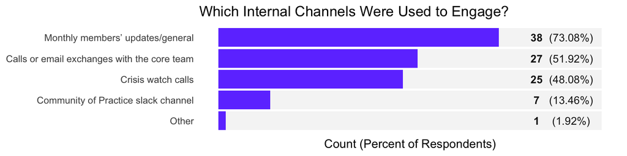

### Comments on This Question

Evidence Aid

We can’t access the SharePoint platform

Insecurity Insight

AGM

shelter centre

contact partner directly

Statistics Without Borders

SWB tries to particpate on monthly calls.

### Question 6

Would you like to propose any new topics for communities of practice, for learning webinars or workshops?

### Comments on This Question

The Humanitarian Leadership Academy

working with media

GNC Technical Alliance, Technical Support Team

Due diligence when working with (unfamiliar) Local or National Actors

Global Public Policy Institute (GPPi)

No

RedR UK

Climate Change

DAHLIA

Migration and medias, medias and NGOs relations

CHS Alliance

good to focus on what members are doing in the activations

Handicap international/Humanity & Inclusion

regular update about humanitarian context and challenges

The Geneva Learning Foundation

Learning beyond training

Humanitarian Academy for Development

Partner mapping, co-funding, member consortiums, workshops and information exchange

RE:ACT Disaster Response

We would like to engage more before we can give this question justice

Edge Effect

We focus on LGBTIQ+ inclusion and if you mean things we could offer, it would be in that space. Some speed dating might be interesting.

Integrity Action

Integrating citizens voice and action in responding to crisis

Field Ready

Not at this time but may in the future

Humanitarian Logistics Association

Engaging with donors (of all types)

GISF

No ideas at this time

Inter-agency Network for Education in Emergencies (INEE)

Not at this time

Fundación DARA Internacional

We would find interesting workshops related to data/ information management systems, M&E,

iMMAP France

no

International Health Partners

Discussion over learnings and challenges faced within responses outside of the fund; approaches to fundraising; other members engagement in charters and signatories (i.e. climate charters etc)

CLEAR Global

Engaging local organizations would be a useful topic for a CoP. I feel we could do more on building the evidence base; perhaps one of these types of event could help. (I know there have been efforts through the MAG, but I think not yet a conclusive result.)

DEMAC

How to set up a pool of experts within H2H network that can be quickly mobilized?

Mixed Migration Centre

no

Ground Truth Solutions

The role of independent actors in a system that would prefer to mark its own homework

Humanitarian OpenStreetMap Team (HOT)

No

Livestock Emergency Guidelines and Standards - LEGS

We’d be happy to engage more with members regarding the use and usefulness (or not) of humanitarian standards in general and LEGS in particular (especially as our new edition of the Handbook will be launched this year)

Centre for Humanitarian Leadership

Knowledge translation and research

Evidence Aid

There is so much we need support with but implementation is more difficult - things like business planning, business case development, funding proposals/applications etc.

BBC Media Action

No, time is tight already

Humanitarian Advisory Group

Climate actions, localisation, Diversity and inclusion

Aviation Sans Frontières International

Since years we are working on a new approach of humanitarian last mile air transport which is making NGO (benefiting from the transport) the core of aviation Project Cycle Management, introducing new paradigms and developing methodologies for need and impact assessment. This should help to increase accountability not only in the air transport sector but also in all logistics sectors. Indeed, what we do is to measure the impact of our service to the capacity of the ‘’benefiting NGO’’ to be more efficient in the field, and this approch does not seems to exist in the recently published logistics humanitarian standards. It was clearly explained when we participated to the ‘’accelerator funds’’ but we have been dismissed because we have proposed a new app to assess NGO needs remotely with an innovative approach (a game on airline management transformed into an assessment tool) but we have been told that ‘’app are not innovation’’. Currently, we are setting up -a last mile humanitarian air service for local medical organizations using local air operators in eastern DRC and this is showing that there are still huge needs to be covered in last mile aviation beside what United Nations Humanitarian Air Services is doing.

Insecurity Insight

Finance management

Data Friendly Space

The entire sector could benefit from a focus on earned media. When a situations arises in the sector, the media is often looking for voices to provide unique perspectives but connecting to those professionals rarely happens on purpose.

MapAction

No

Groupe URD

not at this stage. Perhaps, something arounf how to bettre support local and national actors?

Bioport

Not yet

CartONG

Relationships with donors and UN agencies/INGOs? Localization?

shelter centre

localisation

Sphere

Impact, M&E

Research-Aid Networks

Maybe a specific work shop to facilitate within network collaborations

Relief Applications

Shared resources we can share with the network

Statistics Without Borders

organizational strengths which other members can benefit from.

Internews

advocacy & informing humanitarian structures & standards - what do we really want to disrupt?

Fondation Hirondelle

subsidiarity of decisions and action instead of localisation

Groundwater Relief

Yes - for us it would be useful if workshops could be arranged to look at common administrative challenges that small charities face including foreign payments, insurance, logistics

HQAI

not yet

Relief Applications

Technology use in the humanitarian sector

### Question 7

Would you like to make any other suggestions concerning the future development of members’ services?

### Comments on This Question

The Humanitarian Leadership Academy

please create more workshops and webinars

GNC Technical Alliance, Technical Support Team

Opportunities for less structured interaction - perhaps a type of speed-dating at a less busy time of year

Global Public Policy Institute (GPPi)

No

RedR UK

Net Zero

DAHLIA

To cover more Latine America crisis

CHS Alliance

Keep focussed on emergency scale up

CALP Network

No

Handicap international/Humanity & Inclusion

non

ACAPS

not sure

The Geneva Learning Foundation

More transparency on access to pooled H2H funding

Humanitarian Academy for Development

Please see response to Q21

RE:ACT Disaster Response

As before we would wish to engage more before we can answer this

Edge Effect

It would be great to have more ways to engage with other members, including ways that we can join from Australia.

Integrity Action

Not sure

Field Ready

None come to mind at this time.

Humanitarian Logistics Association

Communications support

GISF

Not at this time

Inter-agency Network for Education in Emergencies (INEE)

No further suggestions come to mind at this time.

iMMAP France

As mentioned earlier, he short duration of the projects combined with the financial and administrative requirements (e.g. small envelopes per project, financial reports to be provided for a 3-month project, impossibility to procure assets, threshold of the DSA rates, specific exchange rate to be used…) bring some difficulties for the teams to develop and implement the actions. It would be great if the projects could be longer and/or the administrative requirements become more flexible (to fit the crisis response)

Medical Aid films

not yet - very new to the network

International Health Partners

No

CLEAR Global

It would be good to revisit the earlier idea (around the DRC activation) of program development/fundraising for specific multi-member projects where relevant.

DEMAC

Further support collaboration between the members of H2H

Mixed Migration Centre

no

Ground Truth Solutions

Opportunities to collaborate on systems strengthening between disasters - would be interesting if someone would fund that (properly)

Humanitarian OpenStreetMap Team (HOT)

No

Livestock Emergency Guidelines and Standards - LEGS

None at present

Centre for Humanitarian Leadership

No

Evidence Aid

Can’t think of anything off the top of my head - sorry

BBC Media Action

Not now, thank you

Humanitarian Advisory Group

It would be great to work out how to better to connect members in geographical areas, such as the Indo-Pacific

Aviation Sans Frontières International

Our suggestion was that H2H Network should actively lobby institutional donors validating the added-value of the services offered by its members, and for its members it will be a kind of certification.

Insecurity Insight

It would be really helpful to have a list of key consultants that understand H2H organizations for auditing, legal advice, help communication, evaluations etc. It would be really helpful if there was a list of people to look at when we seek a specific service

Data Friendly Space

Fund activation is important for the network but I would like to see more prompting of potential mergers of similar organizations. At least let’s ask if there isn’t

MapAction

Made earlier in form

Groupe URD

no idea at this stage

Bioport

Not yet

CartONG

Continue developing shared visibility on members’ activities beyond crisis responses

shelter centre

website dashboard displaying real-time information from from member

Sphere

no

Research-Aid Networks

No

Relief Applications

no

Statistics Without Borders

SWB can provide a review of organizational surveys, data collection proactices, analysis of data, etc.

Internews

/

Fondation Hirondelle

no

Groundwater Relief

Networking event

HQAI

we are wondering whether H2H is thinking about passporting options for members who already have gone through various due diligence (DD) processes and/or are CHS certified. The could be an opportunity to walk the talk and be an example for the wider sector, esp donors

### Question 8

Have you previously applied to the H2H Fund?

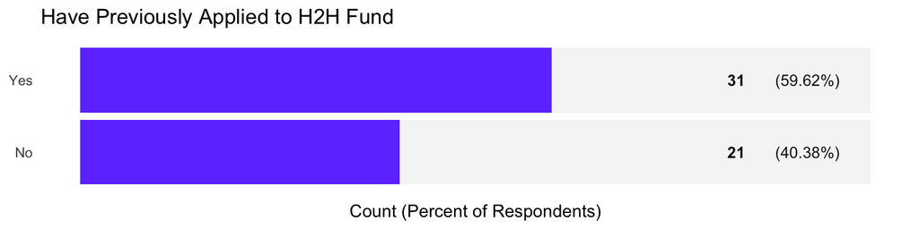

### Comments on This Question

GNC Technical Alliance, Technical Support Team

Score:1

For Tigray, Ethiopia; we were successful but then couldn’t get the contract in place due to issues with wording with our former host :(

Global Public Policy Institute (GPPi)

Score:1

This was in the initial stages, when we discussed if there could be a real-time review mechanism funded as part of H2H.

RedR UK

Score:1

Turkey & Syria Earthquake response

CHS Alliance

Score:1

Syria Turkey earthquake

CALP Network

Score:0

H2H funding isn’t quite the right fit for CALP

ACAPS

Score:1

COVID-19, Tigray, Palestine, HoA

IMPACT Initiatives

Score:1

Horn of Africa in 2022, Armenia in 2020

Humanitarian Academy for Development

Score:1

2020: Remote Capacity Building of Iraqi, Syrian & Yemeni NGOs to adapt to COVID-19 context; 2021: Locally Driven Support to Gaza; 2022: Drought in the Horn of Africa

Field Ready

Score:1

Pacific tropical cyclone response

Humanitarian Logistics Association

Score:1

Innovation fund

iMMAP France

Score:1

iMMAP applied and obtained funding in the past to implement a project in Ethiopia and Burkina Faso.

The New Humanitarian

Score:1

We have applied 8 times and received 6 grants so far (1 application is pending).

International Health Partners

Score:1

We have applied for oPt, Haiti, HoA, and Türkiye / Syria activations. The oPt bid was successful

CLEAR Global

Score:1

We have applied for multiple activations, mostly successfully.

DEMAC

Score:1

Applied in 2022 for Somalia drought response and in 2023 for Syria

Mixed Migration Centre

Score:1

Covid-19 response

Ground Truth Solutions

Score:1

We applied for various emergencies (Haiti, Burkina), Covid, now Syria. We applied for innovation funds for climate but never heard back. This year we applied for less activations (we didn’t put our hands up for Pakistan or the Horn) but are always so grateful for this important funding stream.

Humanitarian OpenStreetMap Team (HOT)

Score:1

Haiti activation, 2022

Livestock Emergency Guidelines and Standards - LEGS

Score:1

We applied unsuccessfully in 2020 for one of the innovation funds

Evidence Aid

Score:1

Covid, Horn of Africa, Pakistan flooding

Humanitarian Advisory Group

Score:0

We are still unsure if we are eligible to apply

Aviation Sans Frontières International

Score:1

See previous answers

Insecurity Insight

Score:1

We have been part of several activations. Maybe 4.

MapAction

Score:1

Covid funding. Successful.

Groupe URD

Score:1

for the development of training (MEAL) in 2020 and this H2H accelerator ongoing

Bioport

Score:0

No

CartONG

Score:1

Covid fund (received); Accelerator (missed)

shelter centre

Score:1

four times, each failed

Sphere

Score:1

DRC, COVID, Sahel

Statistics Without Borders

Score:0

SWB cannot accept any funds; this is written in the SWB charter.

Internews

Score:1

2020: COVID-19 response

Fondation Hirondelle

Score:1

Covid and Pakistan funds

Groundwater Relief

Score:1

Horn of Africa project, emergency preparedness

HQAI

Score:0

since we are not implementers the only fund we can apply for is the accelerator. The last deadline was too short for us, lack of resources to respond

Relief Applications

Score:1

H2H innovation grant

### Question 9

If you have not applied to the H2H Fund, what are the main reasons?

- The process around accessing funding is unclear to you
- The crisis covered by the Fund activations do not align with your operational priorities and capacities
- Your organization had other sources of funding for your response to the crisis covered by the Fund
- The timeframe to submit a project proposal is too short
- The process around submitting an application (narrative proposal, budget, workplan…) is too complex
- The Due Diligence Assessment required to access the fund is too complex or time-consuming
- The amount allocated is too small
- The timeframe to implemented funded projects is too short
- Other (please comment)

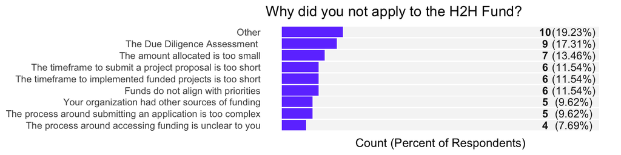

### Comments on This Question

The Humanitarian Leadership Academy

Score:0

I’ve just become aware of the Fund

Edge Effect

Score:0

We are ineligible as per H2H rules.

GISF

Score:0

We received direct funding from the same FCDO pot

Ground Truth Solutions

Score:0

Our team often questions the short windows, but we understand of course the funding constraints

Centre for Humanitarian Leadership

Score:0

CHL is not the right type of org to apply for the Fund

Humanitarian Advisory Group

Score:0

We are not sure as a social enterprise if we are eligible

Data Friendly Space

Score:0

We have been working to provide the needed information for Full Membership.

MapAction

Score:0

We have often been and are about to return home by the time the H2H applications are considered so it is not of use to us due to the time frame of the decision making process being too slow..

Statistics Without Borders

Score:0

SWB cannot accept funds or donations

Internews

Score:0

it’s not always applicable/feasible (which is fine)

HQAI

Score:1

see above

### Question 10

If you applied to the H2H Fund but were unsuccessful, was the feedback you receive useful to help you understand the rationale and improve future applications?

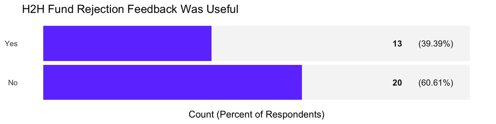

### Comments on This Question

Global Public Policy Institute (GPPi)

Score:1

I came to understand that there was not enough demand / support for a real-time review mechanisms, whether funded through H2H or another mechanism.

Humanitarian Academy for Development

Score:0

Feedback from the Horn of Africa call was ambiguous, greater clarity would ensure we are able to take on board and input the feedback into future funding proposals.

The New Humanitarian

Score:1

We were unsuccessful with our application focused on the Tigray crisis in 2021 and we were told this was based on on the overall fit of the package, which made sense.

CLEAR Global

Score:1

We applied unsuccessfully for the 2nd Covid-19 activation. The feedback was that the 4 organizations in the multi-member project hadn’t sufficiently demonstrated the value added of their collaboration, in addition to their individual services.

Mixed Migration Centre

Score:0

Strange feedback, showing a lack of awareness of what MMC does

Ground Truth Solutions

Score:0

For the small innovation fund, I don’t believe we received any feedback

Evidence Aid

Score:1

Useful, but would be more useful if there could be suggestions of how we rectify this within the network and suggest whom we could work with

Aviation Sans Frontières International

Score:0

Already explained about the ‘’accelerator fund’’. In the reply from H2H Funds there were clear misunderstandings on the side of H2H, like saing that we benefited from institutional funds for the activity when it was clearly stated in the proposal, a simple call or email requesting fro clarifications would have been the solution. Which is of course frustrating when we have invested a huge amount of time. In fact, I remember that this Fund was supposed to help us to remove the main obstacle that we face to go ahead, which is clearly that it is difficult to explain our added value to NGO, and the response of H2H was typically proving this.

Insecurity Insight

Score:1

Our applications weren’t successful twice. In both cases, we felt that the selection panel had perhaps not fully understood the value added of what we proposed but in both cases, I found the process of interacting with H2H staff very helpful.

CartONG

Score:1

Detailed and valuable feedback

Statistics Without Borders

Score:0

SWB cannot accept funding/donations.

HQAI

Score:0

did not apply

### Question 11

How would you assess the transparency of the decision-making process by the H2H Grant Panel with regards to the selection of project proposals?

1 is not at all transparent and 5 is very transparent

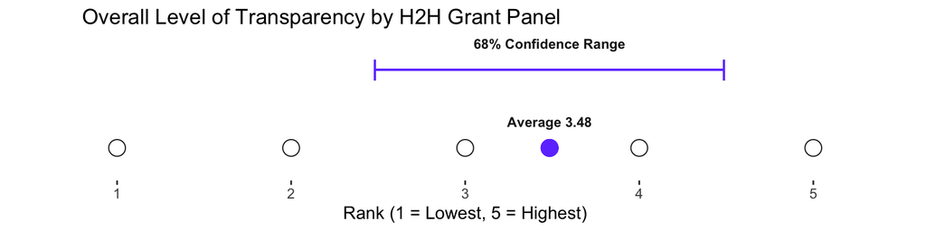

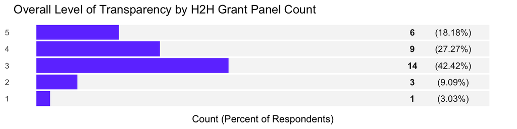

### Comments on This Question

CHS Alliance

Score:3

All good. Was very confused why decision to not include Syria in the last activation call

Humanitarian Academy for Development

Score:3

Please share more details for how funding decisions have been made.

GISF

Score:3

we have not applied for the fund

The New Humanitarian

Score:5

There is usually very good communication about why projects are selected and how the H2H Fund sees them fitting together to address humanitarian needs.

International Health Partners

Score:5

We were very happy with the transparency level from the feedback from unsuccessful H2H activation applications. This is the most detailed feedback we have received from any funder.

CLEAR Global

Score:5

We got candid feedback on our unsuccessful bid; recently we have been given information about panel composition; the selection criteria seem clear and are provided in advance.

DEMAC

Score:2

Would have been interesting to know what projects where selected and why. The qualitative feedback were good to receive, but it could have been good to see the rating for each section

Ground Truth Solutions

Score:4

I think it’s a good process. In the past was a bit biased when UN stakeholders had a big say but were a bit biased

Centre for Humanitarian Leadership

Score:3

I chose 3 because we haven’t applied to the Fund and there wasn’t an option to select to reflect this

BBC Media Action

Score:3

I haven’t followed the process very closely, but in general, it would be helpful to know all criteria up front for selection, including if balanced distribution across members is a factor.

Aviation Sans Frontières International

Score:2

See before

Insecurity Insight

Score:1

I don’t think I understand the selection criteria.

Groupe URD

Score:3

I don’t have a clear knowledge of the process…

CartONG

Score:4

Feedback was great, we could have more information on successful applications to inspire

Statistics Without Borders

Score:3

I cannot answer this question since SWB has not applied for any funding.

Internews

Score:3

I think the crucial part is the justification for activation - less so the actual decision on who gets funding -although H2H definitively communicates about the reasons for activation (so no complaints about that) - the bigger picture ambitions of H2H on where & when it wants to be present might be a good conversation to be had with its members (beyond the availability of donor-money - as the stronger we can articulate our ambition, the more likely donors will actually make money available

### Question 12

If you received a grant, how would you rate the support provided by the core team throughout the Fund activation process, both administrative and programmatic?

1 is not at all helpful and 5 is very helpful

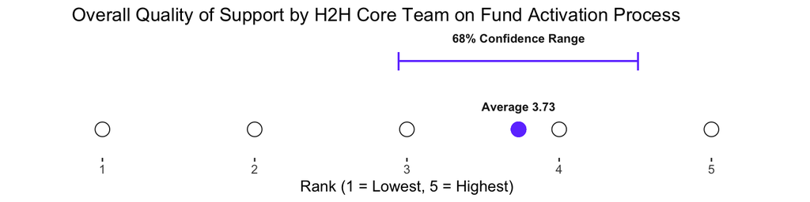

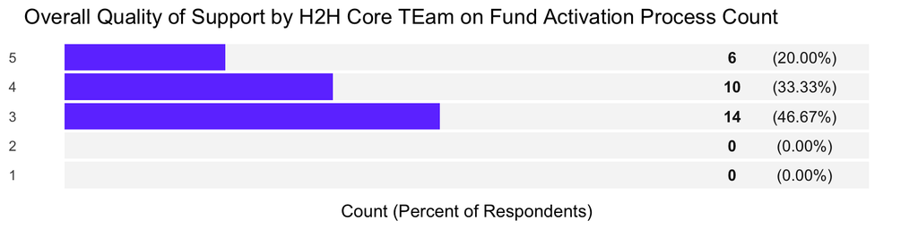

### Comments on This Question

GNC Technical Alliance, Technical Support Team

Score:3

It was mixed - staff were trying to be helpful, but also had rigid structures it seemed from the H2H host organisation.

Humanitarian Academy for Development

Score:5

Excellent level of support, both administrative and programmatic.

GISF

Score:3

we have not applied for the fund

iMMAP France

Score:3

The team is always very easy to reach and supportive when we need guidance.

The New Humanitarian

Score:5

Support has been excellent, the team is very responsive, ensures that we are kept up to date with developments on the activation and what others are doing, and we have found them to also be very understanding and flexible when the situation changes e.g. if we need a no-cost extension due to access issues, for example.

International Health Partners

Score:3

The main contact when we received our grant has left the organisation, so we can’t comment on the last question (27 on support after a successful bid)

CLEAR Global

Score:5

Admin support fantastic: efficient and human. When H2H team members have been able to visit the project area to engage other stakeholders it has helpfully increased awareness and uptake of services and helped build a shared analysis across funded member orgs; the 1:1 program meetings seem a good development. Generally a good balance between not overburdening while still supporting and ensuring due diligence, which is a tricky balancing act to achieve.

Ground Truth Solutions

Score:4

Very helpful and engaged

Humanitarian OpenStreetMap Team (HOT)

Score:3

Responsive, but fairly complicated

Centre for Humanitarian Leadership

Score:3

Again - N/A option not available

Evidence Aid

Score:3

We found the Covid fund very time consuming in terms of reporting

Insecurity Insight

Score:4

Overall, really helpful. Always very constructive.

Groupe URD

Score:4

the process seems heavy/bureaucratic at some stages

CartONG

Score:4

Due diligence still a bit complex (even for a structured organization like us) but H2H team was helpful

Sphere

Score:4

Support from the Team was always good but the level of admin/reporting way too high for the level of funding.

Relief Applications

Score:5

The team has been always very helpful, listening to our needs and acting proactively.

Statistics Without Borders

Score:3

I cannot answer this question since SWB cannot apply for any grants or funding.

Internews

Score:4

support on administrative level has been good - programmatically it was less prominent (which can be a choice) - although also not absent

Fondation Hirondelle

Score:3

it was good to get help re: screening and other donor’s requirements

Groundwater Relief

Score:4

Very helpful in terms of helping us with a project extension and also checking in to see how the project is going.

Relief Applications

Score:4

The support was great; quite challenging to engage with other members

### Question 13

Would you like to make any other suggestions concerning the future development of the fund or the directions it could take?

### Comments on This Question

The Humanitarian Leadership Academy

Promote this resource more

GNC Technical Alliance, Technical Support Team

For us, funding is an important concern, but we almost always can find funds for ‘deployments’, its other important costs that are more difficult to cover that would be helpful if H2H could explore ways to support H2H members in some way. Not only as a readiness fund, but considering that most donors hold very little funds for non-UN agencies at a global level, but that many members cannot access country or regional funding streams for those core costs.

Global Public Policy Institute (GPPi)

no

RedR UK

..

DAHLIA

To include latine america, evaluations, training

CHS Alliance

Grow it!

CALP Network

No

Handicap international/Humanity & Inclusion

non

ACAPS

scenarios to support future of the projects

The Geneva Learning Foundation

use skip patterns (logic) in Typeform so we don’t have to go through irrelevant questions :) not a big deal

Humanitarian Academy for Development

More focus on capacity building and institutional strengthening, as several funding calls have not been relevant to this area.

RE:ACT Disaster Response

We would seek to understand it before we make a suggestion

Edge Effect

Consider opening the fund to social enterprises and other for-profit members where they can make commitments to operate activities on a non-profit basis. We have arrangements like this with bilateral donors.

Integrity Action

Sharing impact and lessons learned in quickly digestible form

Field Ready

With such small grants, the limits placed on the budget (specifically, the small percentages on HQ and indirect costs) should be reconsidered.

Humanitarian Logistics Association

Develop approach to support system building activities

GISF

Not at this time

iMMAP France

no

International Health Partners

More flexibility for diverse outputs in application criteria (i.e. other than data sharing)

CLEAR Global

See above on member services: it could be interesting to revisit the idea of supporting joint project development between members and potentially helping ‘market’ the results to other donors.

DEMAC

More information about the rating of the application

Mixed Migration Centre

no

Ground Truth Solutions

Just that we think it’s vital and will continue advocating for it

Humanitarian OpenStreetMap Team (HOT)

No

Livestock Emergency Guidelines and Standards - LEGS

None at present

Centre for Humanitarian Leadership

No

Evidence Aid

Again, not off the top of my head

BBC Media Action

Not now

Humanitarian Advisory Group

It would be great to see how H2H uphold Grand Bargain commitments

Aviation Sans Frontières International

It depends from were you get your own funding. For the time being it seems that it is always the same process same timing same type of service providers

Insecurity Insight

I think it is working quite well. There are lots of other things that could be done but at the end of the day it comes down to resources and capacity so I am not sure it would be realistic to come up with a big new plan. I think it is working pretty well given available resources.

Data Friendly Space

It would be great to have larger fund activations working to bring more actors to the table.

MapAction

Needs to be core/less specific. We don’t know exactly what costs will be when deploying in a hurry, so precise budgets can be a trap for us. Also we like many h2H members are relatively small so anything less than 25% towards core is not practical and does put us off applying. We are subsidising H2H projects from limited unrestricted funding and this is not helpful.

Groupe URD

happy to discuss it further but no idea right now…

Bioport

Not yet

CartONG

Continue the diversification beyond crisis calls (capacity building, support to the sector, encourage synergies between H2Hs…)

shelter centre

make them more suited to small organisations; streamline donor DDA; remove cap for small agencies

Sphere

no

Research-Aid Networks

If there was an opportunity for collaborative project building more generally, instead of just acute crisis response, that would be helpful.

Relief Applications

Talk with the winners which kind of assessment is more needed so the coaching sessions can be more oriented since the beginning

Statistics Without Borders

No. Thank you

Internews

Nothing I would put into a survey - but I think it could be good to have a discussion about it during our meeting at the HNPW

Fondation Hirondelle

be more flexible

Groundwater Relief

Working with members to develop funding proposals that could be taken to larger donors that are not emergency response based.

HQAI

no

### Question 14

Overall, do you believe there is greater awareness of the network than one year ago? Please share details in the comment box (operational agencies at HQ or response levels; donors; local and national actors)

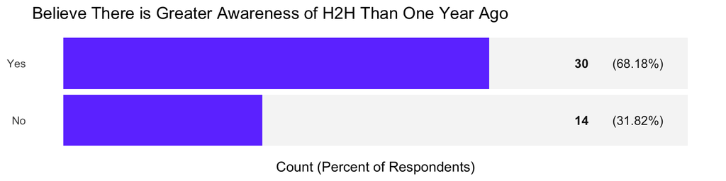

### Comments on This Question

GNC Technical Alliance, Technical Support Team

Score:0

In my network, very few people know about H2H

ACAPS

Score:1

Local and operational partnres have been introduced to H2H through our projects

The Geneva Learning Foundation

Score:1

No way to gauge perception by others

Humanitarian Academy for Development

Score:1

Useful platform and several new members

RE:ACT Disaster Response

Score:1

I can only speak for our own team and we have a greater awareness.

Humanitarian Logistics Association

Score:1

Awareness could be greater if there was a stronger focus / capacity for comms

Inter-agency Network for Education in Emergencies (INEE)

Score:1

Further visibility of the network.

CLEAR Global

Score:0

Honestly it’s hard to say. In meetings with donors and bigger organizations I often find they’ve not heard of the network (which we then describe and promote, of course!). But it may be that in Pakistan or Somalia there is now greater awareness, for instance: as we work mainly remotely, we probably miss a lot of that.

DEMAC

Score:1

More humanitarian stakeholders know about H2H

Ground Truth Solutions

Score:1

I think awareness could still improve. I think many know of H2H but don’t quite ‘get’ it

Centre for Humanitarian Leadership

Score:1

I have heard more people speaking of the network, especially in INGO circles

Evidence Aid

Score:0

We don’t regularly find people who know about H2H

Humanitarian Advisory Group

Score:1

The new website and networking is elevating the profile of members

Aviation Sans Frontières International

Score:0

I don’t have.

Insecurity Insight

Score:1

I am not sure I have a concrete example, but I think we are slowly raising awarness.

Data Friendly Space

Score:1

H2H feels like it has really established itself as a key network in the sector. There is really strong brand recognition in a short period of time.

MapAction

Score:0

I simply don’t know to be honest.

Groupe URD

Score:0

I really don’t know…

CartONG

Score:1

The concept seems to start to be known even though mostly via the biggest members of the network (still no perception that we are all on the smae category despiste size/type of activity)

Sphere

Score:1

H2H comes up regularly in conversations with partners and donors

Relief Applications

Score:1

I see more interaction between the members and more interest in what other members are doing

Statistics Without Borders

Score:1

Manybe it is SWB’s awareness of more humanitarian organizations

Internews

Score:1

Haven’t seen a reason to think there has been a significant increase - but surely the longer it exists, the more people are aware of it. There was no option to write “not sure”, but that in and of itself is maybe telling: did H2H make a big splash in 2022?

Fondation Hirondelle

Score:0

donors still think in silo, humanitarian organizations too

Groundwater Relief

Score:1

We have been promoting the fund through our engagement on the Horn of Africa project.

HQAI

Score:1

more a personal perception; increased visibility on events, social media etc

### Question 15

How do you communicate to operational agencies, donors and local/ national actors about the H2H Network and your role as a member?

### Comments on This Question

The Humanitarian Leadership Academy

by using the h2h hashtag on our social media posts

GNC Technical Alliance, Technical Support Team

In informal communication

Global Public Policy Institute (GPPi)

We do not communicate this.

Handicap international/Humanity & Inclusion

H2H approach is prioritized for the HI’Atlas Logistique Direction

ACAPS

We often add a footnote on our products that they are funded through H2H. We also mention on our website.

The Geneva Learning Foundation

We do not, might occasionally mention it in informal dialogue

Humanitarian Academy for Development

We include projects in our marketing material when implementing, otherwise little communication until a funding call is released

RE:ACT Disaster Response

We will share on SM in future

Edge Effect

To be honest we have not done this much, partly as our opportunities to be active through H2H have been limited.

Field Ready

We do when we’re funded.

Humanitarian Logistics Association

Informally and in meetings / events

GISF

Provide a brief outline of what H2H is and encourage to look at services available

Inter-agency Network for Education in Emergencies (INEE)

I share information about the network when possible.

Fundación DARA Internacional

Ongoing parterships or the posibility for future partnerships that H2H facilitates are always a plus for donors and other organizations we work with, as they improve our reach in the field and evaluation implementation.

The New Humanitarian

The H2H Network is listed as a partner on our website and we refer to our membership as and when relevant.

Medical Aid films

not sure yet - early days

CLEAR Global

It comes up a lot when presenting our own work and aims in meetings and calls with donors and current and potential partners. This is especially the case when we are discussing areas of work where we have collaborated with other members.

DEMAC

We mention we are part of H2H network and when relevant inform about the network

Ground Truth Solutions

Glowingly. We always advocate for more € to H2H in the face of donors finding small grants hard to administer

Livestock Emergency Guidelines and Standards - LEGS

Listed as one of the networks of which we’re a member when we apply for major donor funding, usually in the context of communications and information sharing

Centre for Humanitarian Leadership

Through education and training that we offer as well as through peak body representations

Evidence Aid

We talk about it in terms of the support the network provides for small agencies

Humanitarian Advisory Group

We haven’t done this yet, but would really like to!

Aviation Sans Frontières International

In 2019 and 2020 we refered about our membership to the H2H Network on the cover page of our reports related to the assessment of NGO last mile humanitarian air transport needs and other official communications

Insecurity Insight

We describe ourselves as an H2H organization. We also often state that we are members of the network. I find it a very useful way to describe our identity.

Data Friendly Space

We note that we are members of the network.

MapAction

I talk about it as a board member and promote it as a potential force for promoting the interests of smaller specialist agencies.

Groupe URD

Well… I’m doing it only when communicating about H2H funded activities but not beyond that.

Bioport

Sensibilisation

CartONG

Mentioned on most communication (leaflet, website, presentations, etc.) and used to define us in the sector (not for communication to general public). Usually not detailed on our involvement

shelter centre

email footer

Sphere

regular mentions

Research-Aid Networks

Included in all material we provide and sometimes mentioned in person, depending on the context.

Relief Applications

We use social media but we are planning to make it more visible on our website

Statistics Without Borders

email

Internews

As an interesting network with a diverse set of expertise of agencies who offer support to the humanitarian system to improve service delivery

Fondation Hirondelle

on our website

Groundwater Relief

Through project work. But would be helpful to have more information on how the H2H network might support an intervention as collective and how it might be engaged.

HQAI

narrative reporting; social media; website

Relief Applications

No formal communication; some social media links

### Question 16

From your perspective, which activities most effectively support external engagement for the network and the H2H approach?

- External communications
- Events at global/HQ levels
- Deployment
- Other

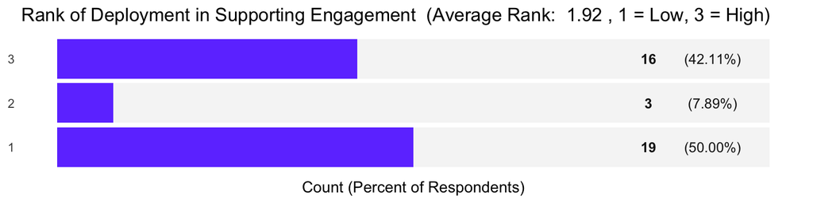

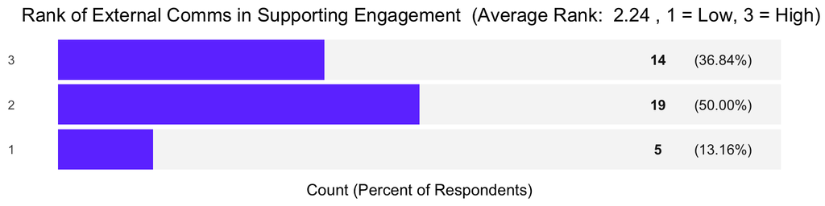

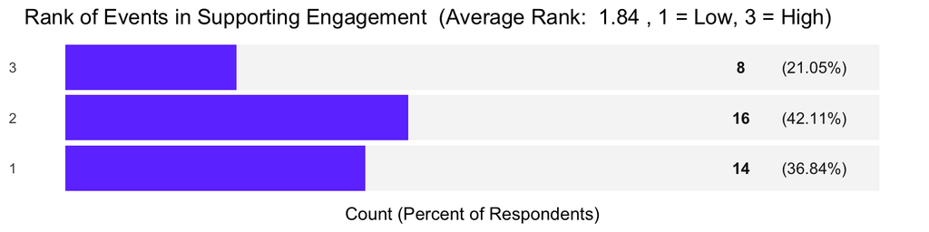

### Comments on This Question

CLEAR Global

Score:Deployment ,Events at global/HQ levels ,External communications

Just because the humanitarian system as it stands is internationally dominated, sadly international events remain a big piece of the influencing puzzle.

Insecurity Insight

Score:Events at global/HQ levels ,External communications ,Deployment

It depends a bit which stakeholder awareness we are thinking about. The ranking would be different for global or in country operations or journalists

Statistics Without Borders

Score:Events at global/HQ levels ,External communications ,Deployment

SWB does not deploy nor can SWB attend in-person events since SWB has no funding to support these events.

Internews

Score:Deployment ,Events at global/HQ levels ,External communications

showing by doing is the most sustainable way of building a reputation - but it does go slowly - however, it would maybe also be against the spirit of what essentially are “support” agencies ?

Groundwater Relief

Score:Deployment ,Events at global/HQ levels ,External communications

Actions speak louder than words

### Question 17

Which external channels do you use to engage with the network?

- Social media
- Website
- Public newsletter
- Events
- Other

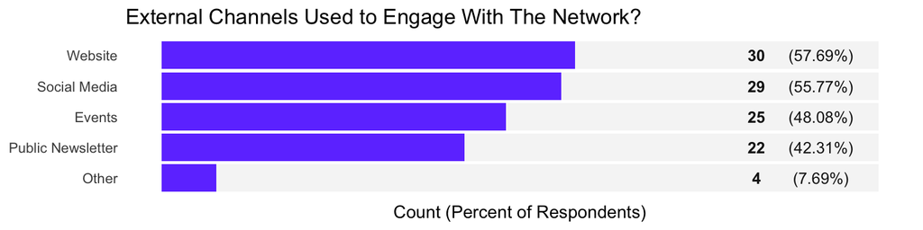

### Comments on This Question

Humanitarian Academy for Development

Emails

BBC Media Action

None - I just get the emails

Statistics Without Borders

email; phone/skype calls

Groundwater Relief

Emails

### Question 18

From your perspective, in the context of fund activations, which activities most effectively support external engagement?

- Communications package
- Brokering with stakeholders (end-users, donors, partners…)
- Deployment
- Other

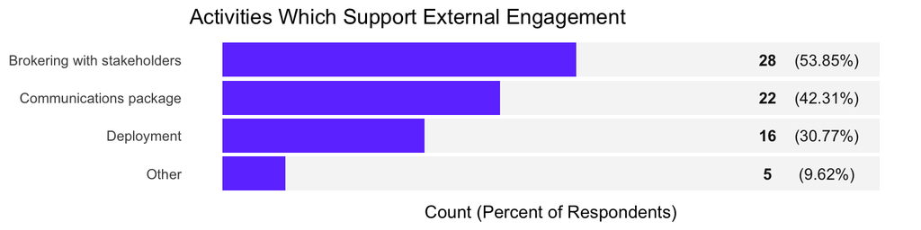

### Comments on This Question

GNC Technical Alliance, Technical Support Team

I’m not sure that I am well enough aware to answer this one well.

Aviation Sans Frontières International

Fast and holistic assessments of real needs and existing solutions

Insecurity Insight

If the end-users from the aid sector actually user our products, this must be the most effective way to raise awareness.

Groupe URD

I don’t know how to respond to this question

Statistics Without Borders

I cannot answer this question since SWB cannot apply for any grants or funding.

### Question 19

Would you like to make any other suggestions concerning the H2H Network’s brokering and facilitation activities?

### Comments on This Question

GNC Technical Alliance, Technical Support Team

No thank you.

CALP Network

No

Handicap international/Humanity & Inclusion

non

GISF

Not at this time

Livestock Emergency Guidelines and Standards - LEGS

None at present

Centre for Humanitarian Leadership

No

BBC Media Action

I don’t really know what they are

Insecurity Insight

Not at the moment.

Data Friendly Space

no comments

CartONG

Not sure if possible but would be interesting to be associated to deployments even if not part of the field activation (if we support remotely)

Relief Applications

no

Statistics Without Borders

no thank you.

HQAI

partner brokering could happen before activations, in a way members are even aware of potential synergies